# 第10回 単回帰・最小二乗法・決定係数

## 回帰分析の出力

1. **開く**：データ → データ分析  
   → 回帰分析 → OK
2. **範囲**：Y に C1:C6、X に B1:B6
3. **出力**：ラベルにチェック  
   一覧の出力先 K1 → OK
4. **見る**：K1 から右に出力表  
   観測数 5・係数 12 と −2

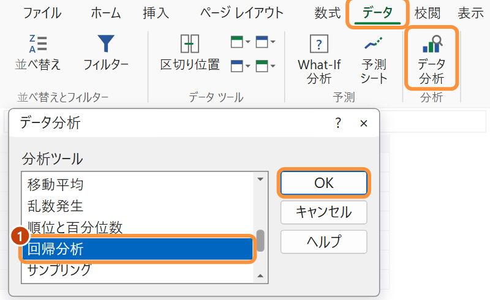

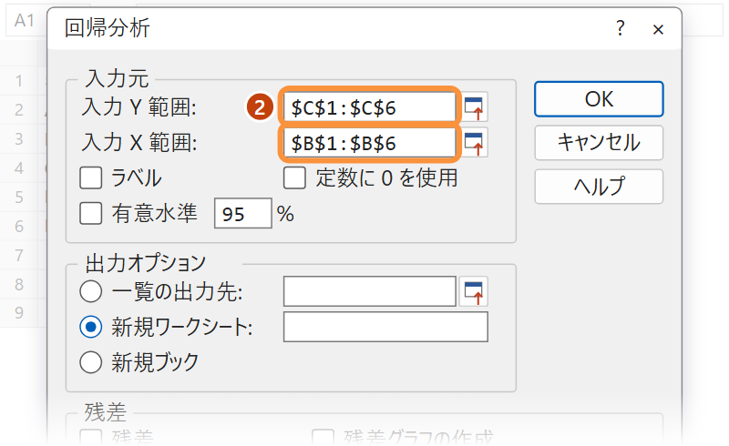

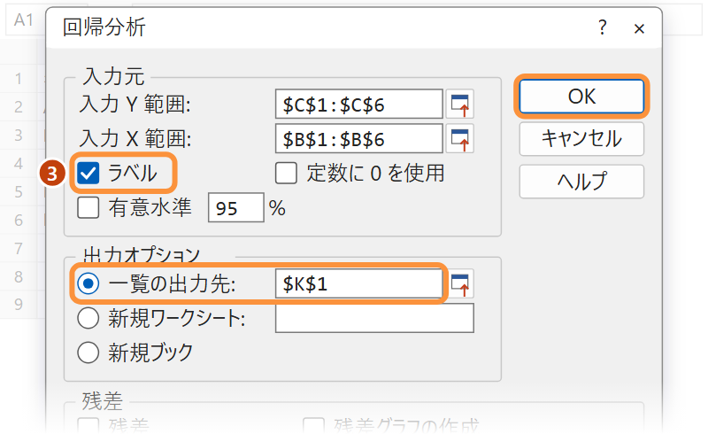

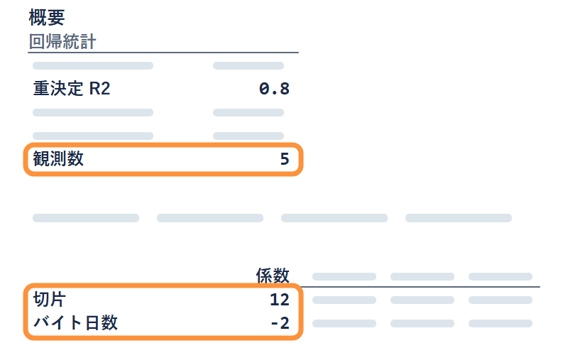

Mac も「データ」タブ →「データ分析」（分析ツールを有効にしてあれば）

✋ 動画を止めて ①〜④ を進め、出力表が出たら再生に戻る

## 出力表で読む所

[figure not shown]

読むのは観測数と係数。薄い所は、この先で読む

## Excel による回帰

**Excel による回帰：関数・グラフ・分析ツール、どれも同じ線**

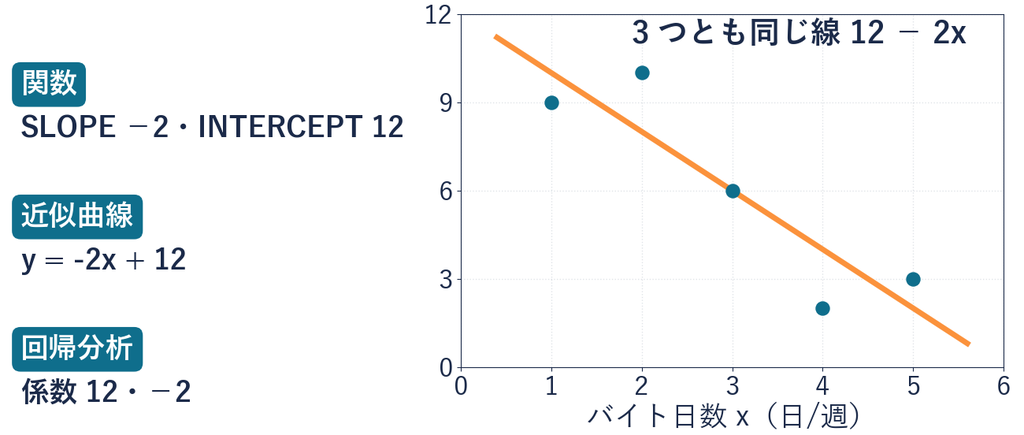

## Q&A 3 つの道具

Q1 観測数が 5 でない

範囲の行がずれている。**C1:C6 と B1:B6**  
（見出しを含めてラベルにチェック）かを見る

Q2 出力表が新しいシートに出た。直しても変わらない

一度消して **「一覧の出力先」に K1** で出し直す。出力表は値なので、  
データを直したらもう一度実行

Q3 近似曲線の項目が出ない

グラフの余白を右クリックしている。**点そのもの**を右クリックする

## 36 年の 3 つの道具

| 道具 | 傾き | 切片 |
| --- | --- | --- |
| SLOPE・INTERCEPT | −0.8588 | 3.6139 |
| 近似曲線の数式 | −0.8588 | 3.6139 |
| 回帰分析の係数 | −0.8588 | 3.6139 |

丸めて書くと、線は 3.614 − 0.859 × 完全失業率  
36 年は関数で出し（次の実習）、この表の数と見比べる

## 36 年の傾きの読み方

- **傾き −0.859**：失業率が 1 ポイント高い年は、  
  物価上昇率の見込みが約 0.86 ポイント低い
- **年どうし**：失業率を 1 上げれば物価が 0.86 下がる、  
  とは言っていない。高い年と低い年を並べて比べただけ
- **切片 3.614**：失業率 0% の年は無い  
  （36 年は 2.09〜5.36%）。意味は読まない
- **期間**：1991〜2026 年の年平均から出した線（2026 年は 1〜5 月の平均）

## 36 年の傾きと切片と予測

1. **関数**：I4・I5 に  
   `=SLOPE(C2:C37,B2:B37)`  
   `=INTERCEPT(C2:C37,B2:B37)`
2. **失業率**：I9 に 3.0 を打つ
3. **予測**：I11 に  
   `=I5+I4*I9` → 1.04

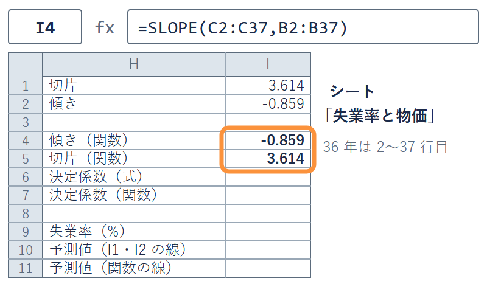

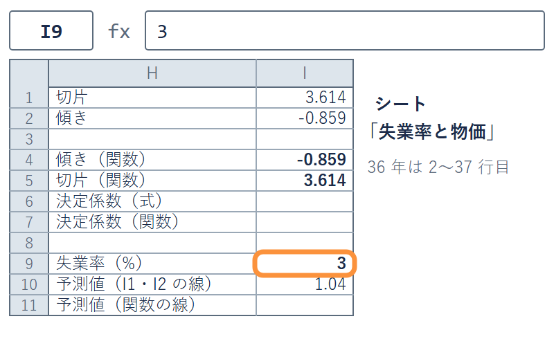

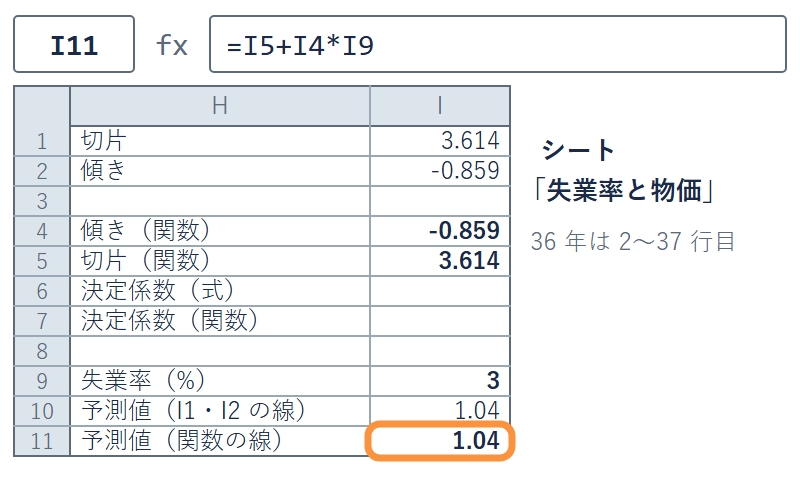

✋ 動画を止めて ①〜③ を進め、1.04 が出たら再生に戻る

y（C 列）が先。I4・I5 は丸めない数で、I10（丸めた線）も 1.04

## 失業率 3.0% の見込み

[figure not shown]

失業率 3.0% の年の、物価上昇率の見込み  
（I11 の予測値）は 1.04%

## 演習 10-3 失業率 5% の見込み

演習 10-3

失業率 5.0% の年の見込みを出し、3.0% の年と比べる

1. **替える**：I9 を 3.0 から 5.0 に打ち替える
2. **見る**：I11 の見込みを読む
3. **確かめる**：3.0 のときの 1.04 から、2 × 0.859 ＝ 1.72 下がったか
4. **答え**：I11 の数を L4 に数字で打つ（画面に見える桁のまま）

見込みがマイナスなら、物価が下がる見込み（データは A1:C37 の 36 年）

## まとめ

- **関数**：SLOPE と INTERCEPT（y の範囲が先）
- **グラフ**：近似曲線の「グラフに数式を表示する」
- **分析ツール**：回帰分析の出力表で、観測数と係数を読む
- **36 年**：3.614 − 0.859 × 失業率。3.0% なら 1.04%

線は道具が引いた。出力表の「重決定 R2」は何の数か  
これを次のトピックで見る

経済データ入門

第10回 — Topic04

決定係数 R²

線の実力を、1 つの数で測る

## この回の道のりと「5人」シート

1

単回帰

演習 10-1

傾きを替えた予測値

2

最小二乗法

演習 10-2

36 年の二乗和

3

分析ツール

演習 10-3

失業率 5% の見込み

4

決定係数

演習 10-4

期間を変えた決定係数

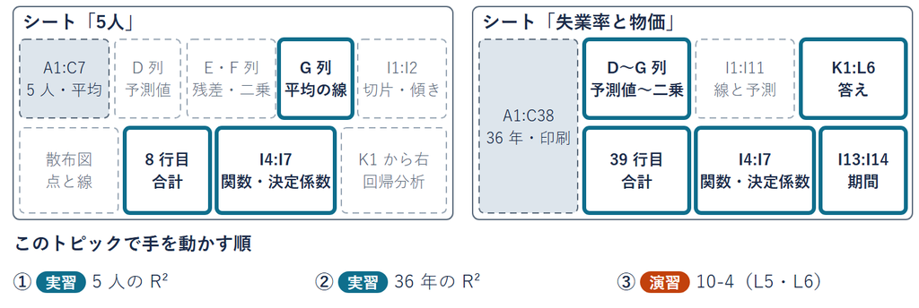

置き場は「5人」の G 列・G8・I6・I7、  
「失業率と物価」の G 列・I6・I7・I13・I14

## 当たり具合の物差し

線は出た。でも 5 人の二乗和 10 は、小さいのか大きいのか

- **比べられない**：5 人の 10 は時間の 2 乗、36 年の 22.13 は % の 2 乗
- **知りたいこと**：線の当たり具合を、単位のない 1 つの数で
- **そこで**：線を引く前と比べる。x を見ずに、  
  誰でも平均で予想する（平均で当てる）

## 平均の線と最小二乗の線

[figure not shown]

x を見ずに平均で当てるより、線で当てるほうが外れが小さい

## 決定係数の手順

手順

STEP 1平均の線の二乗和を出す

STEP 2最小二乗の線の二乗和を出す（T2 の F8）

STEP 31 − 線の二乗和 ÷ 平均の線の二乗和

平均で当てたときの外れのうち、線を引いて消えた割合

## 外れの縮み

[figure not shown]

50 のうち 40 が消えて、10 が残った。消えた割合は 8 割

## 決定係数

**決定係数：平均で当てたときの外れが、線を引いて何割消えたか**

定義

$$\textbf{決定係数}\ R^2 = 1 - \textbf{線の二乗和} \div \textbf{平均の線の二乗和}$$

今回は

$1 - 10 \div 50$

$= 0.8$

記号は R²

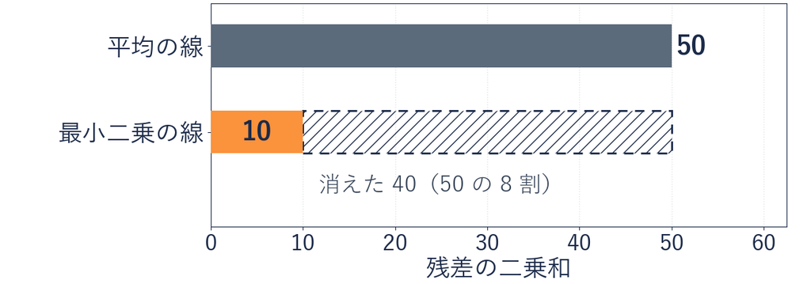

## 決定係数の読み方

- **範囲**：0 から 1 のあいだの数
- **1**：全部の点が線に乗る。外れが全部消えた
- **0**：線を引いても、平均で当てるのと変わらない
- **5 人の 0.8**：ばらつき＝平均の線の二乗和 50。その 8 割の 40 を、  
  バイト日数の線で消せた

## 5 人の決定係数の 2 通り

1. **平均の線**：G2 に  
   `=(C2-$C$7)*(C2-$C$7)` → G6 まで
2. **式で**：G8 に `=SUM(G2:G6)` → 50  
   I6 に `=1-F8/G8` → 0.8
3. **関数で**：I7 に  
   `=RSQ(C2:C6,B2:B6)` → 0.8

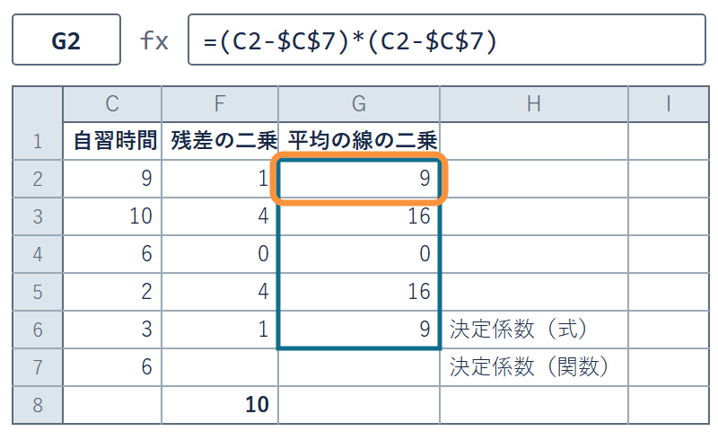

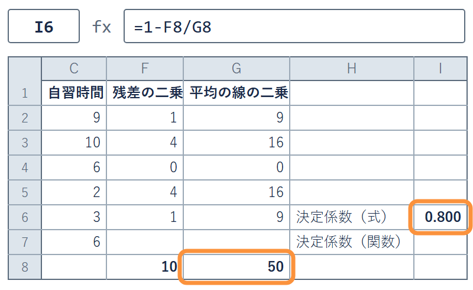

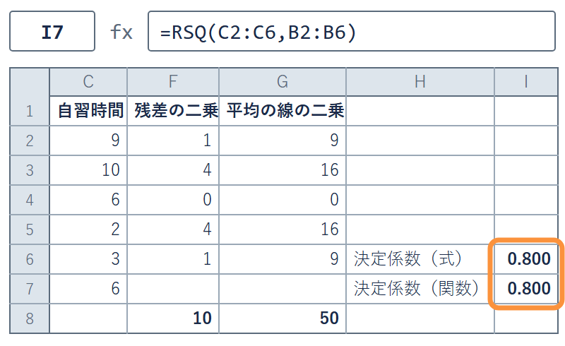

RSQ（y の範囲, x の範囲）：相関係数の二乗。単回帰では決定係数と同じ

✋ 動画を止めて ①〜③ を進め、I6 と I7 が同じなら再生に戻る

## 出力表の重決定 R2

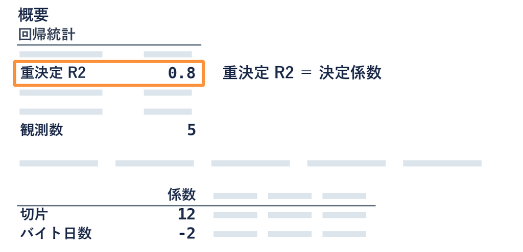

重決定 R2 は R² のことで、0.8。3 通りで同じ数  
「重」は x が 2 つ以上でも使える呼び名

## 決定係数と相関係数

5 人

$(-0.894)^2$

$\approx 0.8$

前の回の r を 2 乗

36 年

$(-0.7373)^2$

$\approx 0.544$

4 桁の r で 2 乗

- **単回帰では**：決定係数 ＝ 相関係数の 2 乗（r ＝ −0.894・−0.7373）
- **x が 1 つのときだけ**：説明に使うもの x が 2 つ以上  
  なら、この関係は使えない
- **違い**：r は向きと強さ。R² は消えた割合  
  R² は 0 以上（マイナスにならない）。向きは r か傾きで見る

## 36 年の外れの縮み

[figure not shown]

平均の線 48.48 から 22.13 へ。R² は約 0.544

## 36 年の決定係数

1. **平均の線**：G2 に → 37 行目まで  
   `=(C2-$C$38)*(C2-$C$38)`
2. **式で**：G39 に  
   `=SUM(G2:G37)` → 48.48  
   I6 に `=1-F39/G39` → 0.544
3. **関数で**：I7 に  
   `=RSQ(C2:C37,B2:B37)` → 0.544

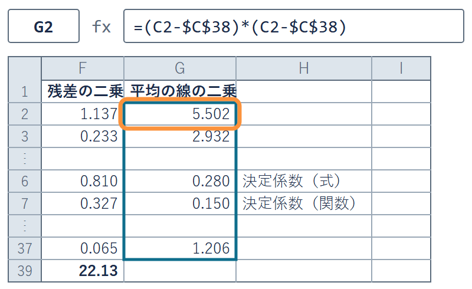

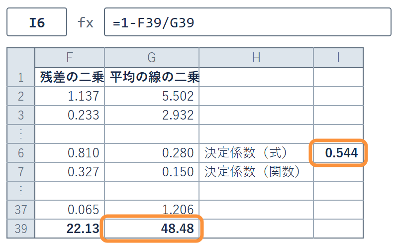

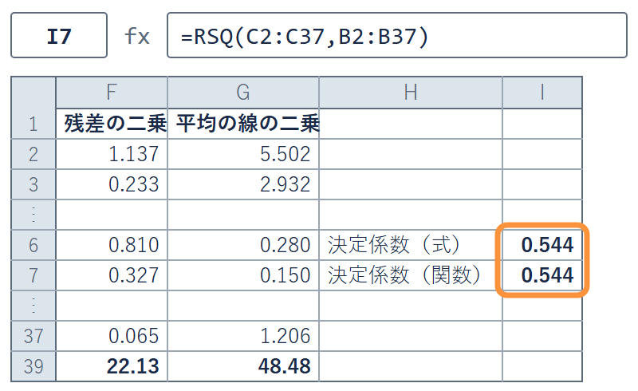

✋ 動画を止めて ①〜③ を進め、0.544 が出たら再生に戻る

シート「失業率と物価」。F 列と F39 は演習 10-2 で作ったもの

## よくある失敗 原因の取り分という読み

**言い過ぎ**  
物価上昇率の 54% は  
失業率で決まる

**正しい読み**  
年ごとのばらつき（48.48）  
の約 54% を  
失業率の線で言い当てた

失業率を下げれば物価が上がる、  
とまでは言えない。線は関係を要約するだけ

## たしかめ 期間を変えた決定係数

36 年のうち、2013〜2019 年の 7 年だけで線を引く  
36 年全部の 0.544 と比べて、決定係数はどうなるか

**1 ほぼ同じ**

**2 高い**

**3 ぐっと低い**

1 つ決めてから先へ。答えは、このトピックの中で出す

## 演習 10-4 期間を変えた決定係数

演習 10-4

期間だけを変えて、決定係数を比べる

1. **前半**：I13 に `=RSQ(C2:C10,B2:B10)`（1991〜1999 年）
2. **後半**：I14 に `=RSQ(C24:C30,B24:B30)`（2013〜2019 年）
3. **答え**：I13 の数を L5、I14 の数を L6 に数字で打つ  
   （小数第 2 位まで）

**実データ**：シート「失業率と物価」の A1:C37（1991 年は 2 行目）

## 期間で変わる線

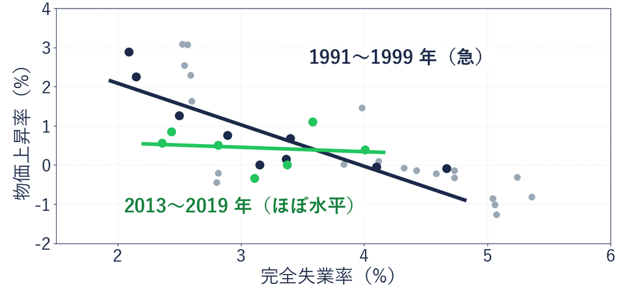

## Q&A 決定係数

Q1 I6 と I7 が合わない

I2 が −2 か（F8 が 10 か）を見る。  
36 年は F39 が演習 10-2 で入っているか

Q2 R² が高ければ、原因と言えるか

言えない。**その期間でよく当たった**、以上を言わない

Q3 r を 2 乗したら 0.543 になった

3 桁の −0.737 で 2 乗した丸めのずれ。**4 桁の −0.7373** なら 0.544

## この回のまとめ

用語

単回帰点の雲を、1 本の線で要約する

最小二乗法ずれを二乗して足し、いちばん小さい線を選ぶ

3 つの道具関数・近似曲線・回帰分析は同じ線を出す

決定係数平均の線の外れが、線で何割消えたか  
（原因の取り分ではない）

「〜で説明できる」と聞いたら、期間を確かめる  
傾き −0.86 を、どこまで信じてよいか。それはこの先で